# Homework 11

Jenna Hussein

2025-02-20

## Instructions

Answer the following questions and complete the exercises in RMarkdown. Please embed all of your code and push your final work to your repository. Your final lab report should be organized, clean, and run free from errors. Remember, you must remove the `#` for the included code chunks to run. Be sure to add your name to the author header above.

Make sure to use the formatting conventions of RMarkdown to make your report neat and clean!

## Background

In the `data` folder, you will find data about shark incidents in California between 1950-2022. The [data](https://catalog.data.gov/dataset/shark-incident-database-california-56167) are from: State of California- Shark Incident Database.

## Load the libraries

```r
library("tidyverse")
library("janitor")
library("naniar")
```

## Load the data

Run the following code chunk to import the data.

```r
sharks <- read_csv("data/SharkIncidents_1950_2022_220302.csv") %>% clean_names()
```

## Questions

1. Start by doing some data exploration using your preferred function(s). What is the structure of the data? Where are the missing values and how are they represented?

```r
summary(sharks)
```

```
##  incident_num           month             day             year
##  Length:211         Min.   : 1.000   Min.   : 1.00   Min.   :1950
##  Class :character   1st Qu.: 6.000   1st Qu.: 7.50   1st Qu.:1985
##  Mode  :character   Median : 8.000   Median :18.00   Median :2004
##                     Mean   : 7.858   Mean   :16.54   Mean   :1998
##                     3rd Qu.:10.000   3rd Qu.:25.00   3rd Qu.:2014
##                     Max.   :12.000   Max.   :31.00   Max.   :2022
##
##      time              county            location             mode
##  Length:211         Length:211         Length:211         Length:211
##  Class :character   Class :character   Class :character   Class :character
##  Mode  :character   Mode  :character   Mode  :character   Mode  :character
##
##
##
##
##     injury             depth             species            comment
##  Length:211         Length:211         Length:211         Length:211
##  Class :character   Class :character   Class :character   Class :character
##  Mode  :character   Mode  :character   Mode  :character   Mode  :character
##
##
##
##
##   longitude            latitude     confirmed_source   wfl_case_number
##  Length:211         Min.   :32.59   Length:211         Length:211
##  Class :character   1st Qu.:34.04   Class :character   Class :character
##  Mode  :character   Median :36.70   Mode  :character   Mode  :character
##                     Mean   :36.36
##                     3rd Qu.:38.18
##                     Max.   :41.56
##                     NA's   :6
```

2. Notice that there are some incidents identified as “NOT COUNTED”. These should be removed from the data because they were either not sharks, unverified, or were provoked. It’s OK to replace the `sharks` object.

```r
sharks_no_unknowns <- sharks %>%
  filter(incident_num != "NOT COUNTED")
```

3. Are there any “hotspots” for shark incidents in California? Make a table and plot that shows the total number of incidents per county. Which county has the highest number of incidents?

```r
sharks_no_unknowns %>%
  group_by(county) %>%
  summarise(total_incidents = n()) %>%
  arrange(-total_incidents)
```

```
## # A tibble: 21 × 2
##    county          total_incidents
##    <chr>                     <int>
##  1 San Diego                    23
##  2 Santa Barbara                19
##  3 Humboldt                     18
##  4 San Mateo                    18
##  5 Marin                        16
##  6 Monterey                     15
##  7 Santa Cruz                   15
##  8 Sonoma                       15
##  9 San Luis Obispo              14
## 10 Los Angeles                   9
## # ℹ 11 more rows
```

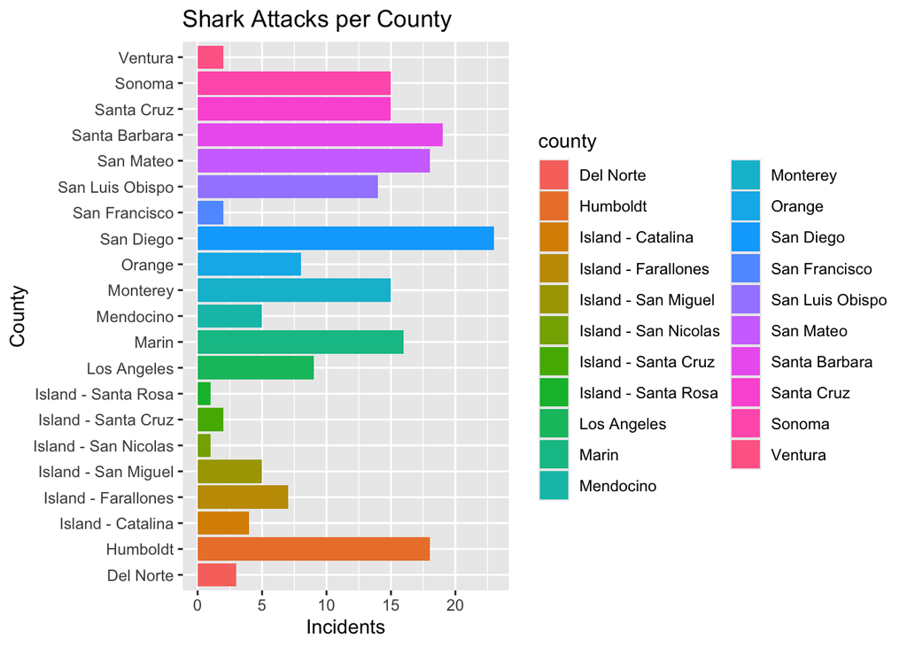

```r
sharks_no_unknowns %>%
  group_by(county) %>%
  summarise(total_incidents = n()) %>%
  arrange(-total_incidents) %>%
  ggplot(aes(x = county, y = total_incidents, fill = county))+
  geom_col()+
  coord_flip()+
  labs(title = "Shark Attacks per County",
       x = "County",
       y = "Incidents")
```

San Diego county has the highest number of incidents.

4. Are there months of the year when incidents are more likely to occur? Make a table and a plot that shows the total number of incidents by month. Which month has the highest number of incidents?

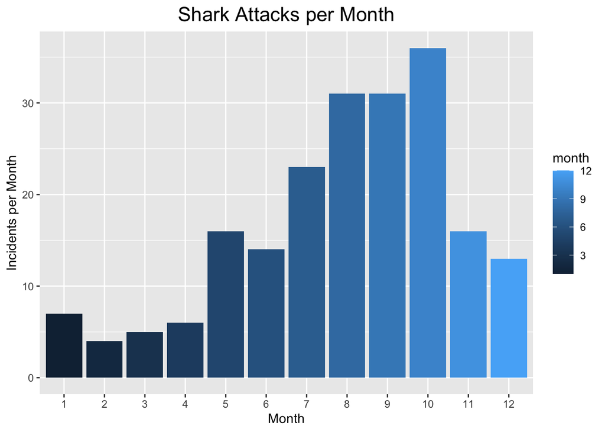

```r
sharks_no_unknowns %>%
  group_by(month) %>%
  summarise(incident_per_month = n_distinct(incident_num, na.rm = T)) %>%
  ggplot(aes(x = as.factor(month), y = incident_per_month, fill = month))+
  geom_col()+
  labs(title = "Shark Attacks per Month",
       x = "Month",
       y = "Incidents per Month")+
  theme(plot.title = element_text(size = rel(1.5), hjust = 0.5))
```

5. How do the number and types of injuries compare by county? Make a table that shows the number of injury types by county. Which county has the highest number incidents?

```r
sharks_no_unknowns %>%
  select(county, injury) %>%
  group_by(county, injury) %>%
  summarise(total_incidents = n(), .groups = 'keep') %>%
  pivot_wider(names_from = injury,
              values_from = total_incidents) %>%
  mutate(total = sum(minor, major, fatal, none, na.rm = T)) %>%
  arrange(-total)
```

```
## # A tibble: 21 × 6
## # Groups:   county [21]
##    county          minor  none major fatal total
##    <chr>           <int> <int> <int> <int> <int>
##  1 San Diego           8     9     4     2    23
##  2 Santa Barbara       6     9     2     2    19
##  3 Humboldt            2     9     7    NA    18
##  4 San Mateo           4    12     1     1    18
##  5 Marin               4     3     9    NA    16
##  6 Monterey            2     3     8     2    15
##  7 Santa Cruz          3     8     3     1    15
##  8 Sonoma              1     6     8    NA    15
##  9 San Luis Obispo     1     7     3     3    14
## 10 Los Angeles         6     2    NA     1     9
## # ℹ 11 more rows
```

San Diego has the highest number of incidents.

6. Use the table from #5 to make a plot that shows the total number of incidents by county.

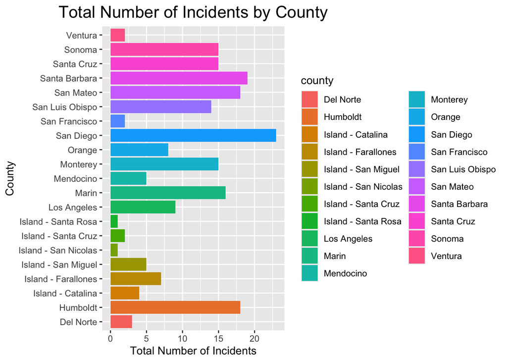

```r
sharks_no_unknowns %>%
  select(county, injury) %>%
  group_by(county, injury) %>%
  summarise(total_incidents = n(), .groups = 'keep') %>%
  pivot_wider(names_from = injury,
              values_from = total_incidents) %>%
  mutate(total = sum(minor, major, fatal, none, na.rm = T)) %>%
  arrange(-total) %>%
  ggplot(aes(x = county, y = total, fill = county))+
  geom_col()+
  coord_flip()+
  labs(title = "Total Number of Incidents by County",
       x = "County",
       y = "Total Number of Incidents")+
  theme(plot.title = element_text(size = rel(1.5), hjust = 0.5))
```

7. In the data, `mode` refers to a type of activity. Which activity is associated with the highest number of incidents?

```r
sharks_no_unknowns %>%
  group_by(mode) %>%
  summarise(total_incidents = n()) %>%
  arrange(-total_incidents)
```

```
## # A tibble: 7 × 2
##   mode                total_incidents
##   <chr>                         <int>
## 1 Surfing / Boarding               80
## 2 Freediving                       35
## 3 Kayaking / Canoeing              29
## 4 Swimming                         22
## 5 Scuba Diving                     19
## 6 Hookah Diving                    10
## 7 Paddleboarding                    7
```

Surfing/ Boarding has the highest number of incidents

8. Make a plot that compares the number of incidents by activity.

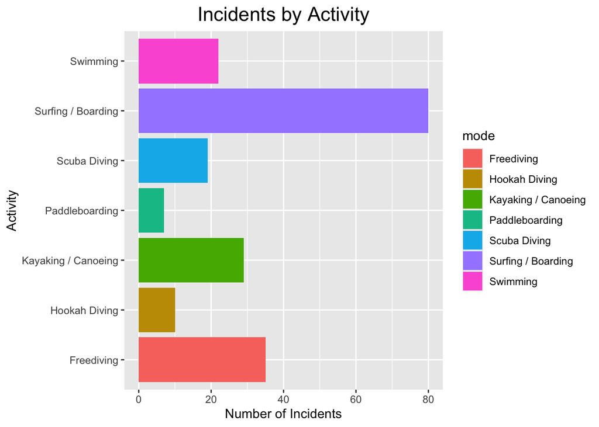

```r
sharks_no_unknowns %>%
  group_by(mode) %>%
  summarise(total_incidents = n()) %>%
  arrange(-total_incidents) %>%
  ggplot(aes(x = mode, y = total_incidents, fill = mode))+
  geom_col()+
  coord_flip()+
  labs(title = "Incidents by Activity",
       x = "Activity",
       y = "Number of Incidents")+
  theme(plot.title = element_text(size = rel(1.5), hjust = 0.5))
```

9. Which shark species is involved in the highest number of incidents?

```r
sharks_no_unknowns %>%
  group_by(species) %>%
  summarise(incidents_per_species = n_distinct(incident_num)) %>%
  filter(species != "Unknown") %>%
  arrange(-incidents_per_species)
```

```
## # A tibble: 7 × 2
##   species    incidents_per_species
##   <chr>                      <int>
## 1 White                        179
## 2 Hammerhead                     3
## 3 Blue                           2
## 4 Leopard                        2
## 5 Salmon                         1
## 6 Sevengill                      1
## 7 Thresher                       1
```

White species is involved in the highest number of incidents.

10. Are all incidents involving Great White’s fatal? Make a plot that shows the number and types of incidents for Great White’s only.

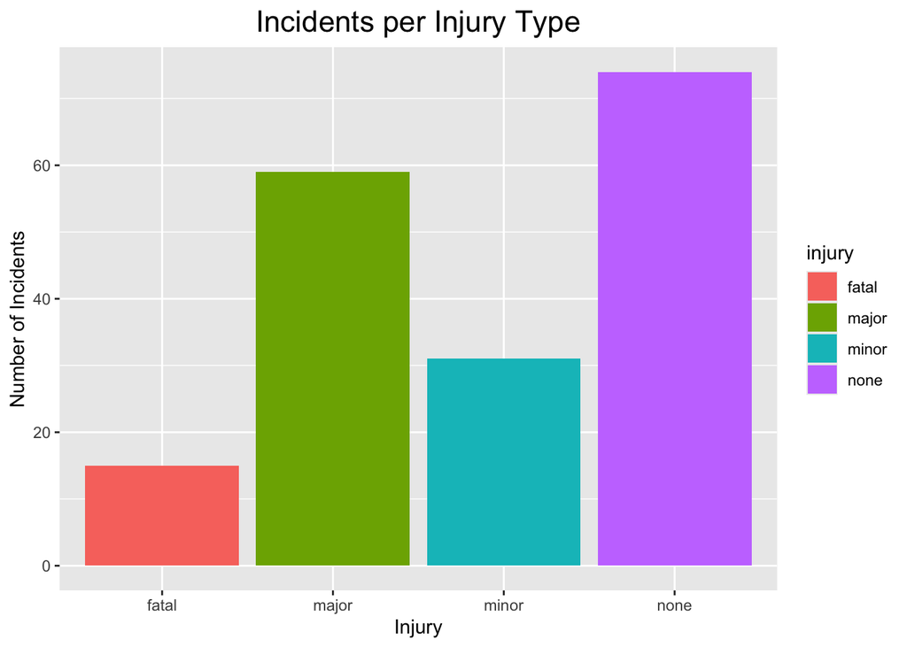

```r
sharks_no_unknowns %>%
  group_by(species, injury) %>%
  summarise(incidents_per_species = n_distinct(incident_num), .groups = 'keep') %>%
  filter(species == "White") %>%
  ggplot(aes(x = injury, y = incidents_per_species, fill = injury))+
  geom_col()+
  labs(title = "Incidents per Injury Type",
       x = "Injury",
       y = "Number of Incidents")+
  theme(plot.title = element_text(size = rel(1.5), hjust = 0.5))
```

No, not all incidents involving a Great White Shark are lethal.